# Dictionary of disease ontologies

Liesbeth François, Jonathan van Eyll and Patrice Godard

UCB Pharma, Braine-l’Alleud, 1420, Belgium

liesbeth.francois@ucb.com

April 15 2020

# 1 Introduction

Disease ontologies have been developed to meet the need to structure, classify, and describe diseases (Gruber 1993; Haendel et al. 2018; Hoehndorf, Dumontier, and Gkoutos 2013). As a result of the diversity in their usage a multitude of disease ontologies exist, aiming to facilitate the integration with drug information, transcriptomics and genomics information, etc. as well as to support development of novel treatments (Haendel et al. 2018; Hoehndorf, Dumontier, and Gkoutos 2013; Rappaport et al. 2013). Disease ontologies allow a more formal description of diseases; however, each ontology often defines an independent identifier and will only link to a subset of independent biological databases (Hasnain et al. 2014; Hoehndorf, Dumontier, and Gkoutos 2013; Kibbe et al. 2015; Livingston et al. 2015; Malone et al. 2010; Rappaport et al. 2013). While this stimulated the construction of integrated biological knowledgebases, the use of independent, ontology-specific identifiers, heterogeneous decisions on disease definitions, and the inherent presence of errors complicates integrating disease ontologies (Livingston et al. 2015; Rappaport et al. 2013). In addition, the navigation of these large integrated knowledgebases with often an inheritely complicated data model, is difficult for most, non-expert users (Hasnain et al. 2014; Hu et al. 2017; Livingston et al. 2015).

Several efforts have been made to connect the different disease ontologies themselves by generating of a single new integrative ontology (Mungall et al. 2017; Shefchek et al. 2019; Rappaport et al. 2013). Using semantic similarity the Monarch Disease Ontology (MonDO) aggregates different sources including OMIM, Orphanet, NCiT, GARD, DO, and MF (Mungall et al. 2017; Shefchek et al. 2019). Other examples is the Disease Ontology (DO) resource which aims to standardize disease descriptions and classification from a clinical perspective using equivalence mappings (Cheng et al. 2013; Schriml and Mitraka 2015; Yu et al. 2015). The Experimental Factor Ontology (EFO) also establishes an unified ontology (not limited to diseases) by re-using several reference ontologies that lie within its scope. It subsequently enriches these classes with additional axioms when needed (Malone et al. 2010). Currently, it combines information from OMIM, Orphanet, ICD9/10 and SNOMEDCT, HPO, UBERON, and MonDO (Ochoa 2019).

Despite ongoing efforts, two issues remain to use disease ontologies efficiently: the issue of completeness and ease of access. To this end, the Dictionary of Disease Ontologies (DODO) was developed. The first issue of completeness concerns the exhaustiveness of disease cross-reference mappings (Hu et al. 2017; Rappaport et al. 2013). While efforts such as the Monarch Initiative and EFO try to integrate different disease ontologies through semantic learning and manual curation, these resources, like the different disease ontologies themselves, are currently not providing a complete mapping across different disease ontologies. In addition, the existing efforts for integration are not flexible to extend easily to proprietary disease ontologies. DODO combines the information provided by the different ontologies, to enrich cross-reference mappings. It also allows connecting ontologies to each other that have no direct cross-reference mapping between them by indirectly inferring relationships using transitivity. Another challenge is the availability of an efficient and straightforward manner to access disease information through well-established bioinformatics platforms (R or python) (Rappaport et al. 2013; Saqi et al. 2018). Such access could facilitate a more flexible connection to the different life science resources and create a more complete disease landscape. Currently, the programmatic access provided by many ontologies often requires expertise in creating SPARQL queries and a high level of understanding of the underlying databases or data model to be able to generate more complex queries (Hasnain et al. 2014; Hu et al. 2017; Rappaport et al. 2013). The presented database is accompagnied by a R package that allows easy access, exploration, and definition of disease concepts of interest. It can work as the intermediate player to facilitate access and ensure exhaustive extraction of information from other life science databases without the need to harmonize these up front. In this paper we will present DODO graphical database and R package with use cases.

# 2 Methods

## 2.1 Implementation

In this section, an overview is presented of the DODO database and the accompagnying R package.

### 2.1.1 Data model

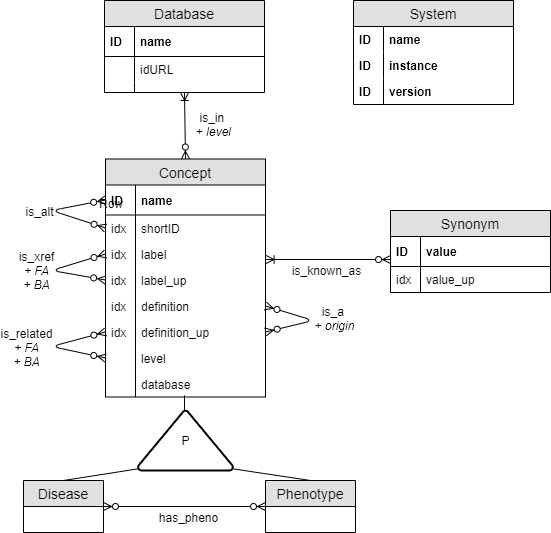

Figure 1: The DODO data model is shown as an Entity/Relationship (ER) diagram  
It consist of four types of entities (concept, disease, phenotype, database) corresponding to graph nodes. Several relationships between the nodes are described referring to graph edges. ‘ID’ refers to an unique entity while ‘idx’ indicates whether this entity is indexed.

The data model underlying DODO aims to capture the relationship between disease and phenotypes as described across different databases (Figure 1). It relies on four types of nodes (concept, disease, phenotype, and database) each with specific proporties. A disease or phenotype node share the same properties. *Name* is a primary property and the full length identifier of a disease or phenotype, a concatenation of database and identifier, e.g. “MONDO:0005027”. Additional properties are (when available) a unique (canonical) *label*, disease *definition*, *database*, and node *type*. In addition, *label_up* and *definition_up* are the uppercase version of *label* and *definition* respectively. When available, a node also has the property of (hierarchical) *level* which captures the lowest level a disease has in the ontological tree. Each node with class disease or phenotype is also encoded with the class “Concept”. Synonyms of the nodes are available through the *is_known_as* relationship with *value* and *value_up* containing the (uppercase) synonyms. A database node has only two property values, its *name* (the name of the database) and url link (*idURL*).

Nodes can be related to each other through different relations based on information provided by the resources. A disease/phenotype/concept node can be related to another node belonging to a different database by the *is_xref* or *is_related* relationship. This relationship indicates nodes relating to the same or highly similar disease concepts (as defined by the original resources). The relationship is directional and has the property *FA* (forward ambiguity) and *BA* (backward ambiguity). As disease definitions can be implemented in a broad or narrow sense by each disease ontology, *is_xref* and *is_related* relationships across ontologies are not always unambiguous. The concept of forward and backward ambiguity is implemented to handle transitivity mapping (see paragraph 2.2.2. The *is_xref* and *is_related* relationship is dependent on the direction one is traversing through and is therefore encoded twice between each node. Each of these directions has its subsequent forward and backward ambiguity information provided as properties.

Phenotype/disease/concept nodes may also be related through *is_a* directional hierarchical relationship identifying parent/child nodes based on an ontological tree. This relationship is only available between nodes of the same database with the exception of diseases defined by EFO. EFO combines the re-use of identifiers from external resources and enriches this information with additional internal disease classifiers to construct its ontology (Malone et al. 2010). To distinguish the origin of the *is_a* relationship, the property *origin* is a added.

Phenotypes are highly detailed descriptions of clinical abnormalities which are used to describe disease through *has_pheno* non-directional relationship. And finally, each disease or phenotype node belongs to a database encoded by the *is_in* relationship. This relationship is assigned the property (hierarchical) *level* capturing the highest position a node has in the ontology tree.

### 2.1.2 Feeding the database

To construct a DODO instance, a set of scripts is available to load and feed a Neo4j instance. These are not exposed directly to the user instead and a general workflow is available in the *build/scripts* folder. The feeding of DODO is based on the parsed files of the different ontologies. The workflow to download and parse each included ontology is available through GitHub soon).

## 2.2 Operation

The data model is implemented using the Neo4j software which uses the Cypher query language (Inc. 2020). An accompagnying R package *DODO* was developed to connect and provides higher level functions to query the Neo4j graph database based on the described data model (paragraph 2.1.1) (R Core Team 2019).

The minimal system requirements are:

- R $\geq$ 3.6
- Operating system: Linux, macOS, Windows
- Memory $\geq$ 4GB RAM

The graph database has been implemented with Neo4j 3.5.14 (Inc. 2020), the DODO R package uses the following packages:

- *dplyr* (Wickham et al. 2019)
- *tibble* (Müller and Wickham 2019)
- *neo2R* (Godard and Eyll 2018)
- *rlist* (Ren 2016)
- *stringr* (Wickham 2019)
- *readr* (Wickham, Hester, and François 2018)
- *visNetwork* (Almende B.V., Thieurmel, and Robert 2019)
- *shinythemes* (Chang 2018)
- *DT* (Xie, Cheng, and Tan 2019)
- *igraph* (Csardi and Nepusz 2006)
- *shiny* (Chang et al. 2019)

### 2.2.2 Transitivity mapping

The concept of *ambiguity* is introduced to identify nodes that have many cross-references to the same database. Cross-reference edges are implemented in a directional manner in Neo4j, therefore both a forward (FA) and backward (BA) ambiguity is calculated and encoded on every direction. As it is often desired to move from a broader concept to a more narrow one, no filtering on forward ambiguity is put in place. However, the opposite, namely moving from a more narrow and through a broader concept is not always wanted. This can result in an exponential increase of converted/expanded identifiers that are only distantly related to the original disease identifier.

In addition to the concept of *ambiguity*, two types of cross-reference edges encoded in DODO: *is_xref* and *is_related*. The *is_xref* edge is used for equal cross-reference relationships where the concepts relate more directly to each other (similar concept definitions). The *is_related* edge is used for all other cross-reference edges. The assignemnt of these edges is based on the maximum value of the sum of forward and backward ambiguities of all cross-references relationships between two databases to quantify the symmetry between them and knowledge of how ontologies deal with and define disease concepts. Ontologies included for this quantification are: MoNDO, EFO, Orphanet, Orphanet, OMIM, MedGen, UMLS, MeSH, ICD10, ICD9, DOID, ClinVar, MEDDRA, GARD, SNOMEDct, and NCIt. The heatmap (Figure 2) shows the $log_{10}$ transformed maximum total ambiguity between ontologies.

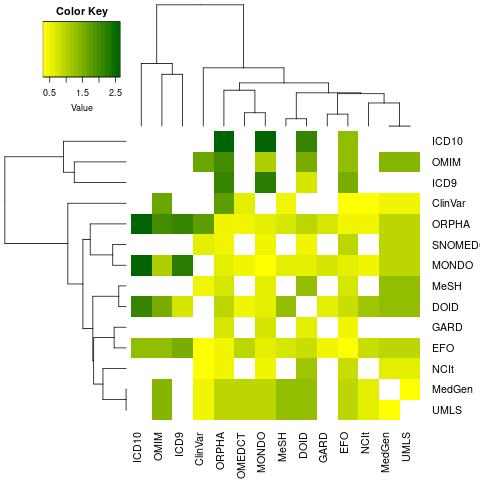

Figure 2: The heatmap shows the maximum value of total ambiguity between ontologies using a $log_{10}$ transformation  
While many ontologies are using concepts of similar level as identified by low total ambiguity, a few can be identified that are more ambiguous in their mappings. The ‘optimal’ ambiguity for a *is_xref* edges is determinged by comparing the number of conversions when incrementally increasing the cutoff of total ambiguity to defining a cross-reference edge between ontologies of either *is_xref* or *is_related* and knowledge of the way disease concepts are defined within ontologies.

The number of conversions per identifier is shown on Figure 3 for MonDO as an example when incrementally increasing the cutoff for the (total) ambiguity to define ontologies connected through *is_xref* and *is_related* edges. A very low cutoff would not return all cross-reference identifiers, while a too high cutoff impact especially a few identifiers strongly with the return of many, more distantly related cross-reference identifiers.

[figure not shown]

Figure 3: Number of conversions comparing incremental cutoffs in the (total) ambiguity to define *is_xref* and *is_related* cross-reference edges on an ontology scale (example of MonDO ontology)

# 3 Results

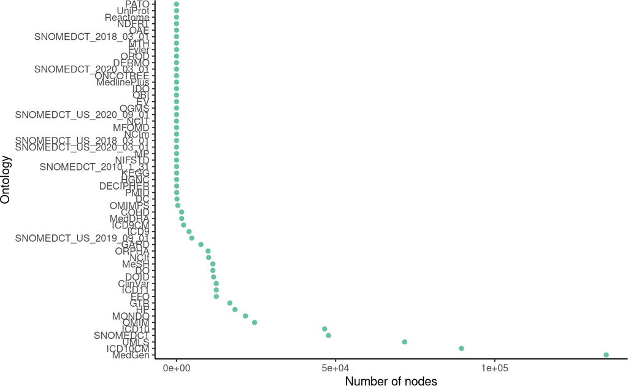

Figure 4: Overview of the number of nodes present for each disease ontology in DODO

# 4 Use cases

## 4.1 Converting concepts

One of the basic functionalities of DODO is the ability to convert disease and phenotype identifiers. The conversion of identifiers is generally performed using a two step process based on the type of cross-reference edges to traverse through and ambiguity values to filter on. Four separate use cases can be identified based on these parameters for converting within the same concept, e.g. converting one disease identifier to other ontologies.

A first and default conversion consists of two steps. The first step uses the transitivity on *is_xref* edges followed by one step expansion using both types of cross-reference edges (parameters “step = NULL” and “intranstivity_ambiguity = NULL”). In Figure 5 an example is presented of the extension starting from the MonDO identifier “MONDO:0005027” encoding for “Epilepsy”. The transitive mapping with filtering on ambiguity moves between the *is_xref* edges (blue) with ambiguity equal to one. The final intransitive mapping step will return all nodes related through either an *is_related* or *is_xref* edge with no filtering (orange) so ambigious relations can also to be returned but not used when extending.

This conversion can be used to get all identifiers around a disease concept whether broadly or narrowly related or when converting from a more narrow concept to a broader concept. In general, when the aim is to reach a broader concept related to the original identifiers but not move through it, it is recommended to put no filter on the *intransitive_ambiguity*. However, for the first step using transitivity mapping on *is_xref* edges it is strongly recommended to use the default filtering on ambiguity by limiting (backward) ambiguity to one.

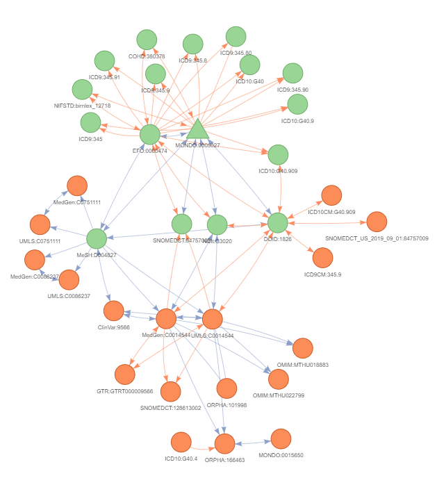

Figure 5: A disNet constructed and subsequently extended using only cross-reference relations using the MonDO identifier for ‘Epilepsy’ (‘MONDO:0005027’) as an example  
This extension is performed in two phases. First, the transitive mapping uses the *is_xref* edges (blue edges) wich are trusted to a larger extend to obtain all relations with filtering on ambiguity (backward ambiguity = 1) (green nodes). The second steps uses no filtering as all relations (ambiguous or not) need to be returned but not used while extending (red nodes). This final intransitive mapping step will return all nodes related through either an *is_related* (orange edges) or *is_xref* edge (blue) with no filtering. The arrows show how nodes can be reached when taking backward ambiguity filtering into account. When there are no arrows present the ambiguity is higher than one and this node can only be reached during the final step of intransitive mapping with no filtering put in place.

A second use case can be identified when the aim is to only get direct cross-references of the identifier of interest withouth using transitivity to return indirect relations (parameter “step = 1”). While transitivity allows the incorporation of information from different ontologies and allows users to connect indirectly related concepts, these relationships might be more vague. This would limit the returned conversion to the nodes indicated in green on Figure 5.

A third use case can be identified when the aim of conversion is to only return equivalent concepts and not return broader disease concepts. This can be a good practise when converting between ontologies that define concept similarly. Here the transitivity mechanism can be employed by parameter ‘step = NULL’ and supplying ‘intransitive_ambiguity = 1’ to ensure that only equivalent edges are traversed in the final step. Figure 6 shows the difference between the default conversion and filtering on the final one step extension.

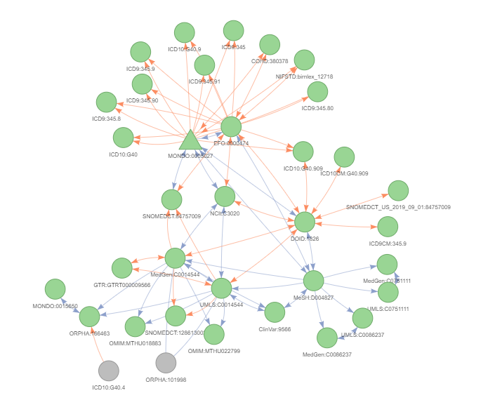

Figure 6: Conversion of ‘MONDO:0005027’ (epilepsy) using transtivity mapping but only returning equivalent concepts in the final step by filtering on intransitive_ambiguity

Finally, a specific conversion procedure is recommended for the ontologies that consider disease concepts that are less connected through *is_xref* edges to the “core” ontologies in DODO (e.g. MonDO, EFO, MedGen, etc.) such as ontologies like ICD10 or ICD9. When converting from these identifiers as a starting point, the conversion will not be able to return cross-reference relationships to all other database. It limits or removes the transitivity mechanism and, therefore, we recommend an additional step to the standard conversion. Implemented in the *get_related* function, an addition expension step through *is_related* and *is_xref* edges is performed before the standard conversion procedure. The ambiguity on this additional step is the same for the final intransitive step in the standard conversion procedure (modified by the *intransitive_ambiguity* parameter). Figure 7 shows the difference between the standard conversion procedure and the recommended procedure on ICD10:G40.9 (Epilepsy). When using the standard conversion only the nodes indicated in green are returned and it is not possible to make use of the transitivity mechanism. By using the recommend *get_related* procedure with an additional expansion step followed by standard conversion, the transitivity mapping can be employed (nodes in orange).

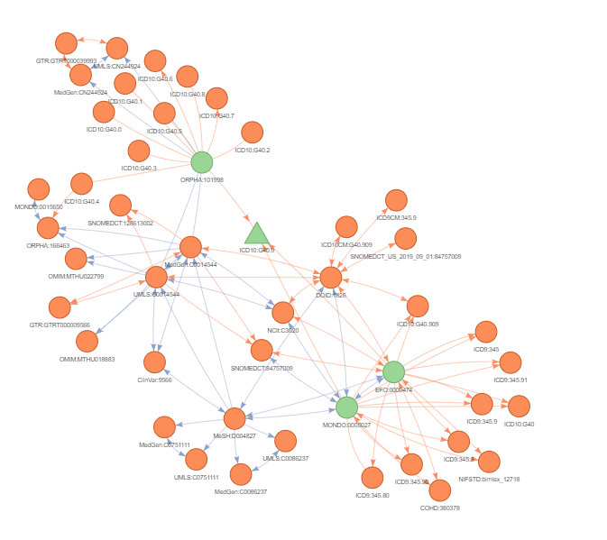

Figure 7: Comparison of the default conversion results with the output of the specific conversion for ontologies with limited connections through is_xref edges (blue edges)  
The example is the ICD10 identifier G40.9 (Epilepsy). The nodes in green signify those return when using the standard conversion. This removes the functionality of the transitive mapping between nodes. Using the recommended procedure implemented in get_related() function with an additional step of expansion before the standard conversion, the transitivity can be employed (nodes in orange). The edges in blue represent is_xref edges, while those in pink present is_related edges between nodes. The arrows show how nodes can be reached when taking backward ambiguity filtering into account. When there are no arrows present the ambiguity is higher than one and this node can only be reached during the final step of intransitive mapping with no filtering put in place.

Conversion can also be used to convert between concept, i.e. from disease identifier to phenotype identifiers or vice versa. This conversion is handled in two distinct phases. First, depending on the options listed above, identifiers are converted within the same concept. When this is not required, using parameter “step = NA” the conversion within the same concept can be avoided. The second phase converts between concepts by returning phenotype or disease nodes directly related to the original identifiers (including the converted identifiers obtain in the first phase).

```r
## From disease to phenotype
toPhenotype <- convert_concept(from = "MONDO:0012391",
                               to = "HP",
                               from.concept = "Disease",
                               to.concept = "Phenotype")
head(toPhenotype)
```

```
#> # A tibble: 6 x 3
#>   from          to         deprecated
#>   <chr>         <chr>      <lgl>
#> 1 MONDO:0012391 HP:0000737 FALSE
#> 2 MONDO:0012391 HP:0002069 FALSE
#> 3 MONDO:0012391 HP:0001249 FALSE
#> 4 MONDO:0012391 HP:0001272 FALSE
#> 5 MONDO:0012391 HP:0000529 FALSE
#> 6 MONDO:0012391 HP:0002059 FALSE
```

```r
## From phenotype to disease
toDisease <- convert_concept(from = "HP:0002384",
                               from.concept = "Phenotype",
                               to.concept = "Disease")
head(toDisease)
```

```
#> # A tibble: 6 x 3
#>   from       to            deprecated
#>   <chr>      <chr>         <lgl>
#> 1 HP:0002384 HP:0002384    FALSE
#> 2 HP:0002384 ClinVar:17141 FALSE
#> 3 HP:0002384 UMLS:C0270834 FALSE
#> 4 HP:0002384 MONDO:0009697 FALSE
#> 5 HP:0002384 MONDO:0009079 FALSE
#> 6 HP:0002384 MONDO:0016825 FALSE
```

Finally, conversion can also be used to return deprecated identifiers when these are available.

```r
deprecated <- convert_concept(from = "HP:0009638",
                               deprecated = TRUE,
                               from.concept = "Phenotype",
                               to.concept = "Phenotype")
head(deprecated)
```

```
#> # A tibble: 2 x 3
#>   from       to         deprecated
#>   <chr>      <chr>      <lgl>
#> 1 HP:0009638 HP:0004079 TRUE
#> 2 HP:0009638 HP:0006073 TRUE
```

## 4.2 Building a disNet

A core concept in DODO is the S3 *disNet* object which contains all information on diseases/phenotypes and their internal relationships. This object can be constructed using helper function *build_disnet* and supplying it with either a vector of disease identifiers or search terms.

```r
disNet <- build_disNet(id = c("MONDO:0005144"))

disNet <- build_disNet(term = "amyotrophic lateral sclerosis",
                       fields = c("label", "synonym"))
```

## 4.3 Extending a disNet

When building a *disNet* by either identifier(s) or search term(s), the resulting *disNet* will likely not contain the complete information on that particular disease landscape. The *extend_disNet* function enriches the disNet and extends it to cross-reference identifiers, child/parent terms, annotated phenotypes/disease, and/or alternative identifieres when available. In concordance with the conversion procedure, extension follows the same two-step approach. Please refer to paragraph 4.1 for more details and the different use cases.

```r
disNet <- build_disNet(id = c("HP:0003394", "HP:0002180", "HP:0002878"))
disNet <- extend_disNet(disNet = disNet, relations = "disease")
disNet
```

```
#> # A tibble: 397 x 7
#>    id      label            definition            shortID level type    database
#>    <chr>   <chr>            <chr>                 <chr>   <int> <chr>   <chr>
#>  1 MONDO:… glycogen storag… "Phosphoglycerate ki… 0010392    11 Concep… MONDO
#>  2 OMIM:6… NEURODEGENERATI… "NEURODEGENERATION W… 610217     NA Concep… OMIM
#>  3 MONDO:… adult-onset dis… "Adult-onset distal … 0018006    10 Concep… MONDO
#>  4 MONDO:… Charcot-Marie-T… "Autosomal dominant … 0011675     9 Concep… MONDO
#>  5 OMIM:6… MOTOR NEURON DI… "MOTOR NEURON DISEAS… 600333     NA Concep… OMIM
#>  6 MONDO:… pure mitochondr… "Pure mitochondrial … 0016807    11 Concep… MONDO
#>  7 ORPHA:… Congenital musc… "Congenital muscular… 258         8 Concep… ORPHA
#>  8 OMIM:3… MITOCHONDRIAL C… "MITOCHONDRIAL COMPL… 301021     NA Concep… OMIM
#>  9 ORPHA:… Nocardiosis      "Nocardiosis is a lo… 31204       4 Concep… ORPHA
#> 10 ORPHA:… Mitochondrial e… " mutation is charac… 1194        9 Concep… ORPHA
#> # … with 387 more rows
#>
#> The disNet contains:
#>  -  394 disease nodes from 6 ontologies and 3 phenotype nodes from 1 ontologies
#>  -  2206 synonyms of the disease nodes
#>  -  0 parent/child edges
#>  -  0 crossreference edges
#>  -  0 alternative edges
#>  -  398 phenotype edges
#>  -  The disNet was build based on 3 seeds
```

## 4.4 Reviewing

It may be required to review the returned *disNet* after building and/or extending it to assess whether all nodes are of interest. This process can be simplified by considering clusters of cross-references (nodes dealing with similar concepts) using the *cluster_disNet* functionality. Instead of reviewing each node, the different cross-reference clusters can be reviewed to identify those of interest while using the relationships between nodes to handle equivalent nodes simultaneously without the need to review them separately). In addition, the process of using cross-reference clusters also allows the revision of identifiers that have no label information attached.

## 4.5 Visualizations

DODO is build as a meta-database incorporating several disease ontologies and their listed relationships. As disease concepts and definitions are not auto-generated but rather a human effort, concepts might not always be clearly defined or related to each other in a straightforward manner. The different ontologies employ hetergeneous definitions, cross-reference axes are not always exact, and errors present in the original ontologies will impact DODO as well. Using the *explore_disNet* and plotting function may increase understanding in how disease are defined across the different ontologies and visualize the relationship between different resources.

# 5 Conclusions

Disease ontologies have allowed a more formal classification of diseases. They facilitate the integration of biological databases thereby increasing disease understanding and supporting the development of novel treatments. However, efforts to integrate biological databases or the ontologies directly are complicated by ontology-specific identifiers, heterogeneous decisions on disease definitions, and the inherent presence of errors. Despite ongoing efforts, we identified two remaning challenges:

- Currently no resource provides a flexible and complete mapping across the multitude of disease ontologies
- Availability of efficient and straightforward software on standard bioinformatics platform (R or python)

DODO database and R package aims to tackle these two challenges by constructing a meta-database containing information on disease identifiers and their relationships across different ontologies. Through the transitivity mechanisms, the information across resources can be used to identify indirect cross-references. The R package contains several functions to build and interact with a disNet or convert concept identifiers between ontologies. While the workflow to construct a custom, local DODO database is provided with the intent to allow adaptation and addition, a docker image with the presented ontologies is provided for ease of use.

We believe that DODO can help clarify and define conditions of interest as well as aid in the understanding of relationships between disease concepts. We hope it improves accessibility of disease ontologies for a standard user. In addition, connecting different biological database (information on compounds, text mining, transcriptomics, etc.) through a disNet facilitates integration. It also ensures these resources are queried using equivalent identifiers of the disease of interest without the user being required to make decisions on these mappings. In addition, it also allows visualizing the connection between these resources directly.

Through the aggregation of different ontologies and their mappings, DODO functions as a meta-database with easy access and possibility to estabblish a more exhaustive disease landscape. The code to build and query DODO is provided under open source license to allow further improvement by other developers.

Almende B.V., Benoit Thieurmel, and Titouan Robert. 2019. “visNetwork: network visualization using vis.js library.” https://cran.r-project.org/package=visNetwork.

Chang, Winston. 2018. “Shinythemes: Themes for Shiny.” https://cran.r-project.org/package=shinythemes.

Chang, Winston, Joe Cheng, JJ Allaire, Yihui Xie, and Jonathan McPherson. 2019. “shiny: Web Application Framework for R.” https://cran.r-project.org/package=shiny.

Cheng, Liang, Guohua Wang, Jie Li, Tianjiao Zhang, Peigang Xu, and Yadong Wang. 2013. “SIDD: A Semantically Integrated Database towards a Global View of Human Disease.” *PLoS ONE* 8 (10): 1–9. https://doi.org/10.1371/journal.pone.0075504.

Csardi, Gabor, and Tamas Nepusz. 2006. “The igraph software package for complex network research.” *InterJournal* Compex Sys: 1695. http://igraph.org.

Godard, Patrice, and Jonathan van Eyll. 2018. “BED: A Biological Entity Dictionary based on a graph data model [version 2; referees: 2 approved].” *F1000Research* 7: 1–32. https://doi.org/10.12688/f1000research.13925.2.

Gruber, Thomas R. 1993. “A Translation Approach to Portable Ontology Specifications.” *Knowledge Aquisition* 5 (2): 199–220. https://ebiquity.umbc.edu/get/a/publication/501.pdf.

Haendel, Melissa A, Julie A Mcmurry, Rose Relevo, Christopher J Mungall, N Peter, and Christopher G Chute. 2018. “A Census of Disease Ontologies.” *Annual Review of Biomedical Data Science* 1: 305–31.

Hasnain, Ali, Maulik R. Kamdar, Panagiotis Hasapis, Dimitris Zeginis, Claude N. Warren, Helena F. Deus, Dimitrios Ntalaperas, Konstantinos Tarabanis, Muntazir Mehdi, and Stefan Decker. 2014. “Linked biomedical dataspace: Lessons learned integrating data for drug discovery.” *Lecture Notes in Computer Science (Including Subseries Lecture Notes in Artificial Intelligence and Lecture Notes in Bioinformatics)* 8796: 114–30. https://doi.org/10.1007/978-3-319-11964-9.

Hoehndorf, Robert, Michel Dumontier, and Georgios V. Gkoutos. 2013. “Evaluation of research in biomedical ontologies.” *Briefings in Bioinformatics* 14 (6): 696–712. https://doi.org/10.1093/bib/bbs053.

Hu, Wei, Honglei Qiu, Jiacheng Huang, and Michel Dumontier. 2017. “BioSearch: a semantic search engine for Bio2RDF.” *Database : The Journal of Biological Databases and Curation* 2017: 1–13. https://doi.org/10.1093/database/bax059.

Inc., Docker. 2019. “Docker Community Edition.”

Inc., Neo4j. 2020. “Neo4j Community Edition.”

Kibbe, Warren A., Cesar Arze, Victor Felix, Elvira Mitraka, Evan Bolton, Gang Fu, Christopher J. Mungall, et al. 2015. “Disease Ontology 2015 update: An expanded and updated database of Human diseases for linking biomedical knowledge through disease data.” *Nucleic Acids Research* 43 (D1): D1071–D1078. https://doi.org/10.1093/nar/gku1011.

Livingston, Kevin M, Michael Bada, William A. Baumgartner, and Lawrence E Hunter. 2015. “KaBOB: ontology-based semantic integration of biomedical databases.” *BMC Bioinformatics* 16 (1): 1–21. https://doi.org/10.1186/s12859-015-0559-3.

Malone, James, Ele Holloway, Tomasz Adamusiak, Misha Kapushesky, Jie Zheng, Nikolay Kolesnikov, Anna Zhukova, Alvis Brazma, and Helen Parkinson. 2010. “Modeling sample variables with an Experimental Factor Ontology.” *Bioinformatics* 26 (8): 1112–8. https://doi.org/10.1093/bioinformatics/btq099.

Mungall, Christopher J., Julie A. McMurry, Sebastian Kohler, James P. Balhoff, Charles Borromeo, Matthew Brush, Seth Carbon, et al. 2017. “The Monarch Initiative: An integrative data and analytic platform connecting phenotypes to genotypes across species.” *Nucleic Acids Research* 45 (D1): D712–D722. https://doi.org/10.1093/nar/gkw1128.

Müller, Kirill, and Hadly Wickham. 2019. “Tibble: Simple Data Frames.” https://cran.r-project.org/package=tibble.

Ochoa, David. 2019. “EFO3: A community-driven ontology to advance clinical discoveries.” [Last visit 26/12/2019]. https://blog.opentargets.org/2019/12/19/efo3-a-community-driven-ontology-to-advance-clinical-discoveries/.

Rappaport, Noa, Noam Nativ, Gil Stelzer, Michal Twik, Yaron Guan-Golan, Tsippi Iny Stein, Iris Bahir, et al. 2013. “MalaCards: An integrated compendium for diseases and their annotation.” *Database* 2013: 1–14. https://doi.org/10.1093/database/bat018.

R Core Team. 2019. “R: A Language and Environment for Statistical Computing.” Vienna, Austria: R Foundation for Statistical Computing. https://www.r-project.org/.

Ren, Kun. 2016. “Rlist: A Toolbox from Non-Tabular Data Manipulation.” https://cran.r-project.org/package=rlist.

Saqi, Mansoor, Artem Lysenko, Yi-ke Guo, Tatsuhiko Tsunoda, and Charles Auffray. 2018. “Navigating the disease landscape: knowledge representations for contextualizing molecular signatures.” *Briefings in Bioinformatics*, no. November 2017: 1–15. https://doi.org/10.1093/bib/bby025.

Schriml, Lynn M, and Elvira Mitraka. 2015. “The Disease Ontology : fostering interoperability between biological and clinical human disease-related data.” *Mammalian Genome* 26 (9). Springer US: 584–89. https://doi.org/10.1007/s00335-015-9576-9.

Shefchek, Kent A, Nomi L Harris, Michael Gargano, Nicolas Matentzoglu, Deepak Unni, Matthew Brush, Daniel Keith, et al. 2019. “The Monarch Initiative in 2019 : an integrative data and analytic platform connecting phenotypes to genotypes across species.” *Nucleic Acids Research* 1: 1–12. https://doi.org/10.1093/nar/gkz997.

Wickham, Hadly. 2019. “Stringr: Simple, Consistent Wrappers for Common String Operations.” https://cran.r-project.org/package=stringr.

Wickham, Hadly, Romain François, Lionel Henry, and Kirill Müller. 2019. “Dplyr: A Grammar of Data Manipulation.” https://cran.r-project.org/package=dplyr.

Wickham, Hadly, Jim Hester, and Romain François. 2018. “readr: Read Rectangular Text Data.”

Xie, Yihui, Joe Cheng, and Xianying Tan. 2019. “DT: a wrapper for the JavaScript Library "DataTables".” https://cran.r-project.org/package=DT.

Yu, Guangchuang, Li Gen Wang, Guang Rong Yan, and Qing Yu He. 2015. “DOSE: An R/Bioconductor package for disease ontology semantic and enrichment analysis.” *Bioinformatics* 31 (4): 608–9. https://doi.org/10.1093/bioinformatics/btu684.